# An introduction to $p$-value functions

Dr. Denis Infanger

denis.infanger@unibas.ch

01 October 2025

## My promises

After this presentation, you will …

- know what $p$-value functions are
- know how $p$-value functions are constructed
- be able to interpret $p$-value functions correctly
- be able to use $p$-value functions to improve statistical and quantitative reasoning
- be able to use $p$-value functions to compare study results

## Research has a problem

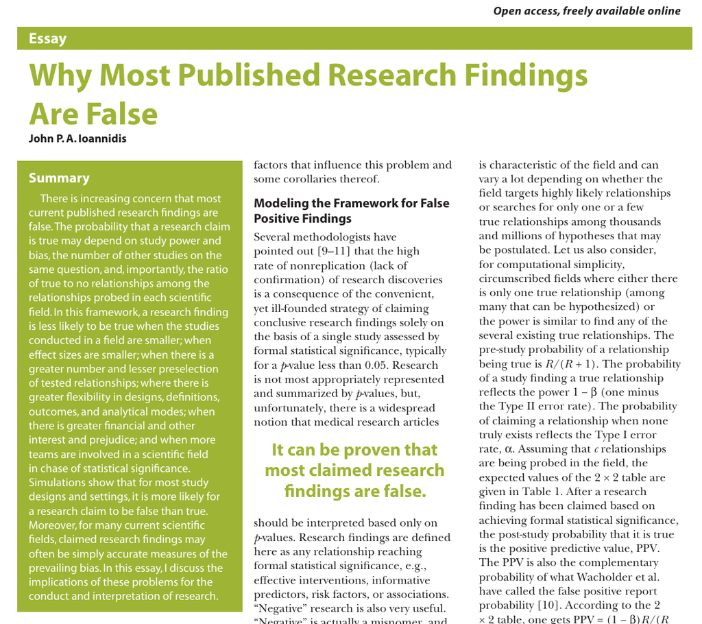

https://doi.org/10.1371/journal.pmed.0020124

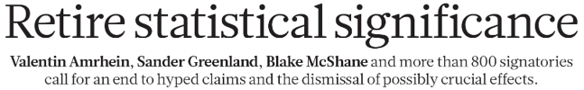

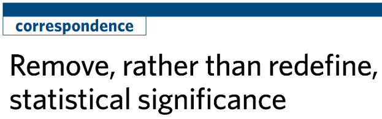

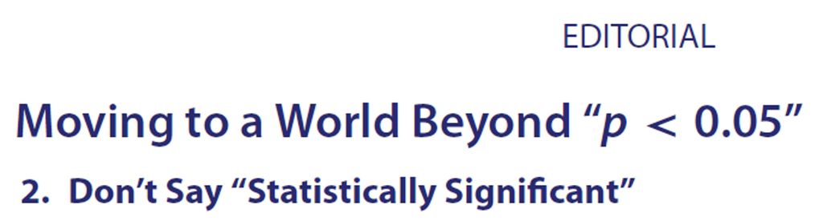

## Many alternatives to classical frequentist statistics and hypothesis testing in particular have been proposed

- Bayesian statistics
- Lowering significance threshold from $0.05$ to $0.005$
- Focus on effect sizes and uncertainty intervals
- *My opinion:* $P$-values are here to stay
  - Improve interpretation of tools that are used
  - $P$-value functions: Graphical tool to achieve that

## $P$-values

**Definition**

$P$ is the probability under the null hypothesis of obtaining a test statistic at least as extreme as the one obtained. “Extreme” means farther from the null value.

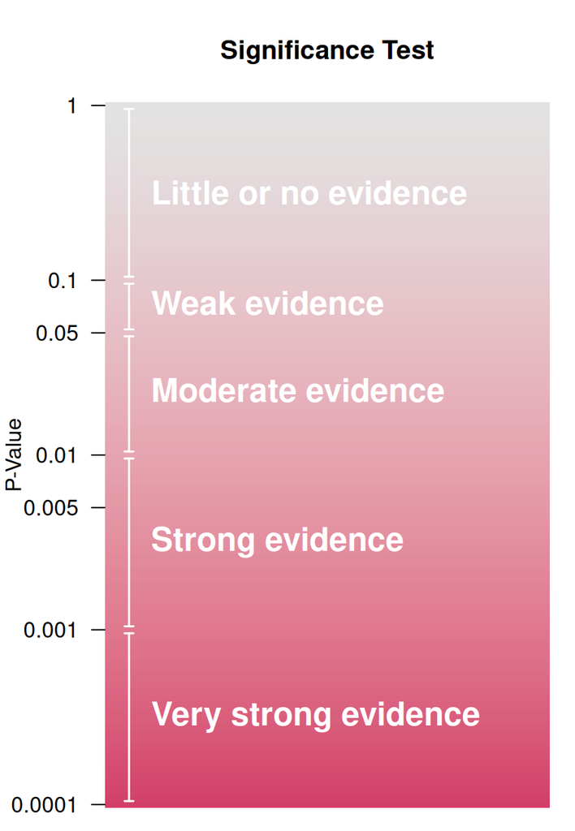

Image adapted [from here.](https://bookdown.org/charlotte_micheloud93/Clinical_Biostatistics/statistical-significance-and-sample-size-calculations.html#the-null-hypothesis-and-statistical-significance)

Informally, $p$-values are a continuous measure of *compatibility* between the data and a hypothesis, given a set of background information (for details, see [here](https://doi.org/10.1186/s12874-020-01105-9)).

## Just one $p$-value?

- “The null hypothesis states that there is no effect/no difference.” No!
- $P$-values in papers often have implicit hypotheses: $\operatorname{H}_{0}:\theta = \color{red}{0}$ vs. $\operatorname{H}_{1}:\theta\neq \color{red}{0}$.
- In other words: The $p$-value is for a test against the *null value* of $0$.
- But: You can calculate $p$-values for other null values too!
- Example: $\operatorname{H}_{0}:\theta = \color{red}{2.5}$ vs. $\operatorname{H}_{1}:\theta\neq \color{red}{2.5}$.

## Confidence intervals and their relation to $p$-values

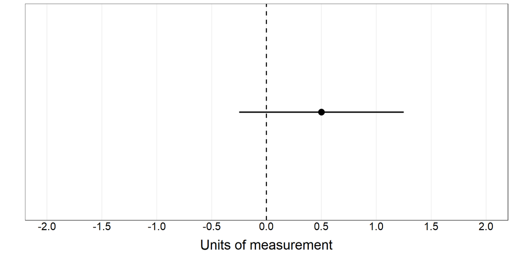

95% Confidence interval for an arbitrary parameter

```r
df <- data.frame(est = 0.5, lwr = 0.5 - 0.75, upr = 0.5 + 0.75)
theme_set(theme_bw())
ggplot(df, aes(x = est, y = 0)) +
  geom_vline(xintercept = 0, linetype = 2, linewidth = 0.75) +
  geom_point(size = 4) +
  geom_errorbarh(aes(xmin = lwr, xmax = upr), height = 0, linewidth = 1) +
  labs(
    x = "Units of measurement"
    , y = ""
  ) +
  scale_x_continuous(limits = c(-2, 2), breaks = scales::pretty_breaks(n = 10)) +
  theme(
    axis.title.y=element_text(colour = "black", size = 19, hjust = 0.5, margin=margin(0,12,0,0)),
    axis.title.x=element_text(colour = "black", size=19, margin=margin(10,0,0,0)),
    # axis.title.y=element_text(size=15,hjust=0.5, vjust=1),
    axis.text.x=element_text(colour = "black", size=15),
    axis.text.y=element_blank(),
    legend.position="top",
    legend.text=element_text(size=20),
    legend.key.size = unit(3, "line"),
    panel.grid.minor = element_blank(),
    panel.grid.major.y = element_blank(),
    legend.key=element_blank(),
    plot.title = element_text(face = "bold"),
    legend.title=element_text(size=20, face = "bold"),
    strip.text.x=element_text(size=20)
    , axis.ticks.x=element_blank()
    , axis.ticks.y=element_blank()
  )
```

- The confidence interval (CI) displays the values that are compatible with the data and the model.
- All values within the CI have $p>0.05$ (are not “significant”).
- Values outside the CI have $p\leq 0.05$ (are “significant”).
- **Q:** What’s the $p$-value for the values at the edge of the CI? $p=0.05$ (for a 95%-CI)

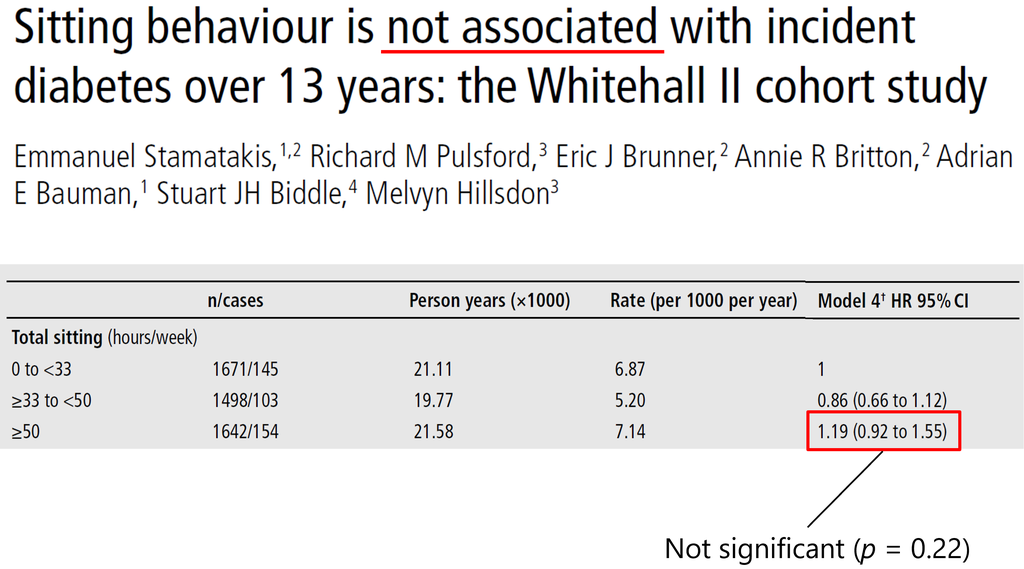

https://doi.org/10.1136/bjsports-2016-096723

## Question

In your opinion, do the results justify the conclusion that there was *no association* between sitting time and diabetes? Why or why not?

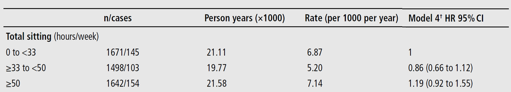

## Confidence intervals

- Confidence intervals: Range of supported/compatible values given the data.
- But:
  - Are all values inside the CI equally well supported?
  - Are all values outside the CI equally badly supported?
  - Why does the support of values decrease sharply at the edges of the CI?

## 95% confidence interval for Stamatakis et al. (2017)

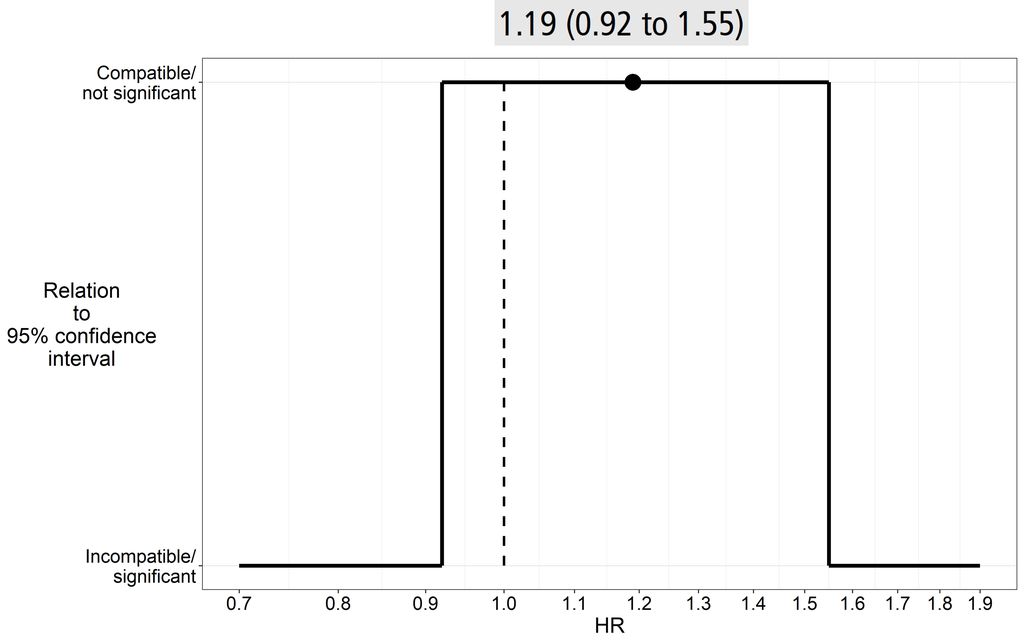

## Some ideas for improvement

- Plot multiple confidence intervals together:
  - 99%
  - 95%
  - 90%
  - …
- Calculate and plot $p$-values for other values than $1$ (the usual null value for ratio measures):
  - For example: $P$-value for $\operatorname{H}_{0}:$ HR = $1.5$ is $0.0975$.

## Plot multiple confidence intervals for the same estimate

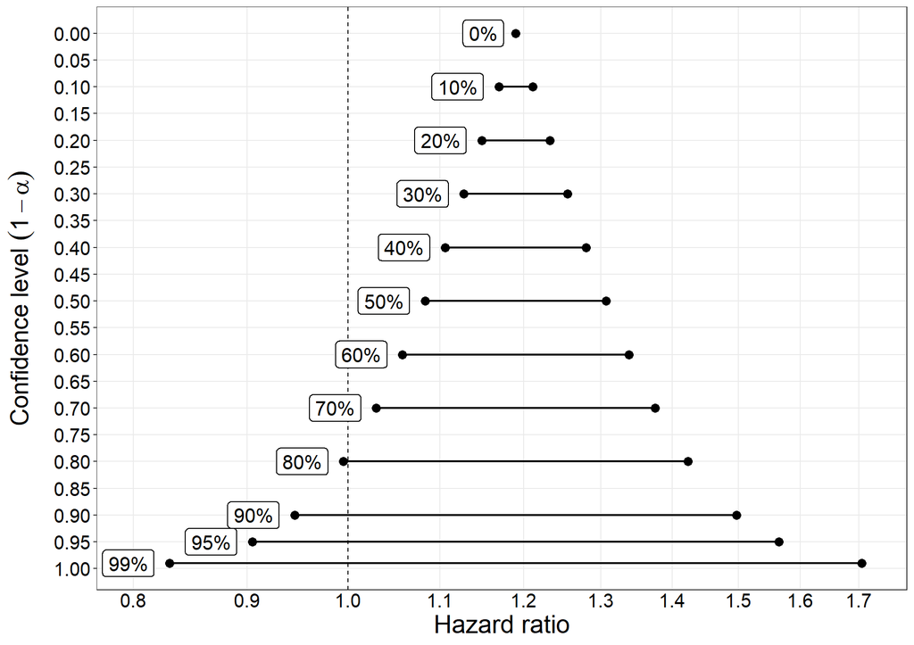

```r
# Stamatakis et al. (2017)

est <- log(1.19)
se <- 0.1397

alphas <- c(0.01, 0.05, 0.1, 0.2, 0.3, 0.4, 0.5, 0.6, 0.7, 0.8, 0.9)

z_vals <- qnorm(1 - alphas/2)

lwr <- est - z_vals*se
upr <- est + z_vals*se

plot_dat <- data.frame(
  pointest = exp(est)
  , lwr = exp(lwr)
  , upr = exp(upr)
  , alphasrev = 1 - alphas
  , alphas = alphas
)

text_frame <- data.frame(
  y = c(plot_dat$alphasrev, 0)
  , x = c(plot_dat$lwr, plot_dat$pointest[1])
)

text_frame$label <- paste0(text_frame$y*100, "%")

scaleFUN <- function(x) sprintf("%.2f", x)

theme_set(theme_bw())
p <- ggplot(plot_dat, aes(y = alphasrev, x = pointest)) +
  geom_blank() +
  geom_vline(xintercept = 1, linetype = 2, linewidth = 0.5) +
  geom_point(aes(x = pointest, y = 0), size = 3) +
  geom_point(aes(x = lwr), size = 3) +
  geom_point(aes(x = upr), size = 3) +
  geom_segment(aes(x = lwr, y = alphasrev, xend = upr, yend = alphasrev), linewidth = 0.75) +
  # geom_vline(xintercept = 1, linetype = 2, size = 0.6) +
  xlab("Hazard ratio") +
  ylab(expression("Confidence level "*(1 - alpha))) +
  # ylab("") +
  scale_x_continuous(breaks = scales::pretty_breaks(n = 10), trans = "log", limits = c(0.8, 1.72)) +
  scale_y_continuous(breaks = seq(0, 1, 0.05), labels=scaleFUN, trans = "reverse") +
  # scale_colour_manual(values = c("#C16700", "#008FD0"),  name = "") +
  theme(
    axis.title.y=element_text(colour = "black", size = 19, hjust = 0.5, margin=margin(0,12,0,0)),
    axis.title.x=element_text(colour = "black", size=20),
    # axis.title.y=element_text(size=15,hjust=0.5, vjust=1),
    axis.text.x=element_text(colour = "black", size=15),
    axis.text.y=element_text(colour = "black", size=15),
    # plot.margin=unit(c(2,2,2,2,2),"line"),
    legend.position="top",
    legend.text=element_text(size=20),
    legend.key.size = unit(3, "line"),
    panel.grid.minor = element_blank(),
    # panel.grid.major = element_line(colour=grey(0.8), size=0.5),
    legend.key=element_blank(),
    plot.title = element_text(face = "bold"),
    legend.title=element_text(size=20, face = "bold"),
    # legend.key.width=unit(.01,"npc"),
    # legend.key.height=unit(.025,"npc"),
    # strip.background=element_rect(fill="white")
    strip.text.x=element_text(size=20)
    , axis.ticks.x=element_blank()
    # , axis.ticks.y=element_blank()
  ) +
  geom_label(
    data = text_frame
    , mapping = aes(x = x, y = y, label = label)
    , fill = "white"
    , inherit.aes = FALSE
    , label.size = 0.5
    , parse = FALSE
    , size = 5.5
    , hjust = 1.3
  )

p
```

## Plot *all* confidence intervals, calculate *all* $p$-values

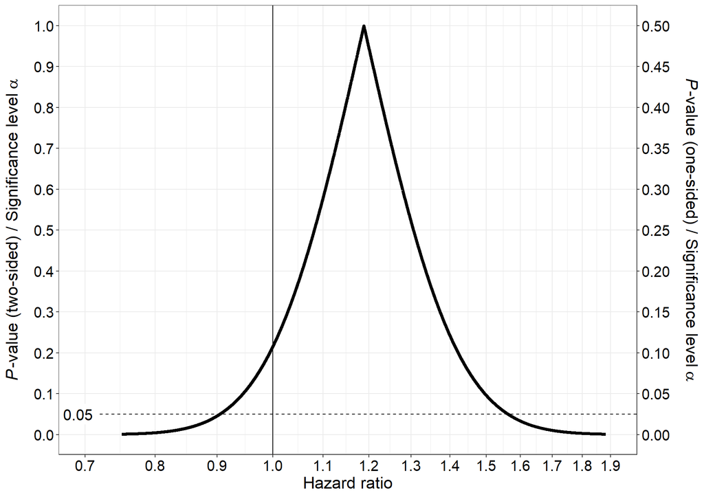

```r
# Now "true" p-value function

stama <- conf_dist(
  estimate = c(
    0.1730998 # Stamatakis total sitting time
    # , log(1.10) # Petersen total sitting time (both sexes)
  )
  , stderr = c(
    # 0.1336387
    0.1397
  )
  , type = "coxreg"
  , plot_type = "p_val"
  , n_values = 1e4L
  , conf_level = c(0.95)
  , null_values = log(c(1))
  , trans = "exp"
  , alternative = "two_sided"
  , log_yaxis = FALSE
  , cut_logyaxis = 0.05
  , xlab = "Hazard ratio"
  , xlim = log(c(0.7, 1.9))
  , together = FALSE
  , plot_p_limit = 1-0.999
  , plot_counternull = FALSE
)
```

## A $p$-value function

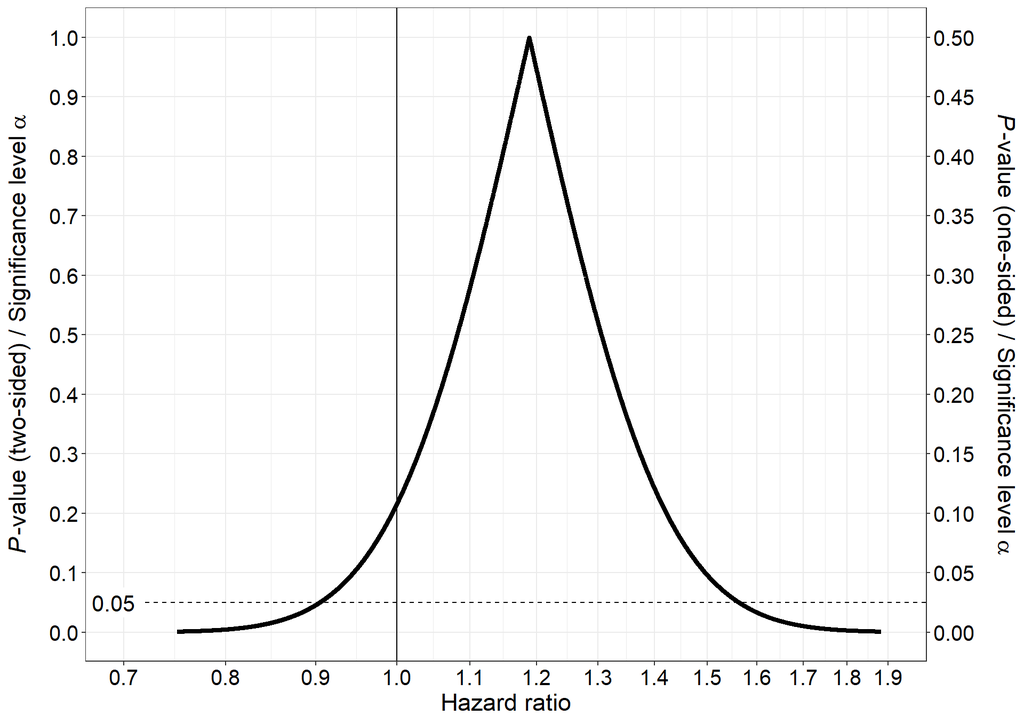

- *All* possible confidence intervals (all confidence levels)
- *All* possible $p$-values (two- and one-sided)
- No arbitrary threshold such as $0.05$.

## The width of the $p$-value function indicates the *precision* of the estimate

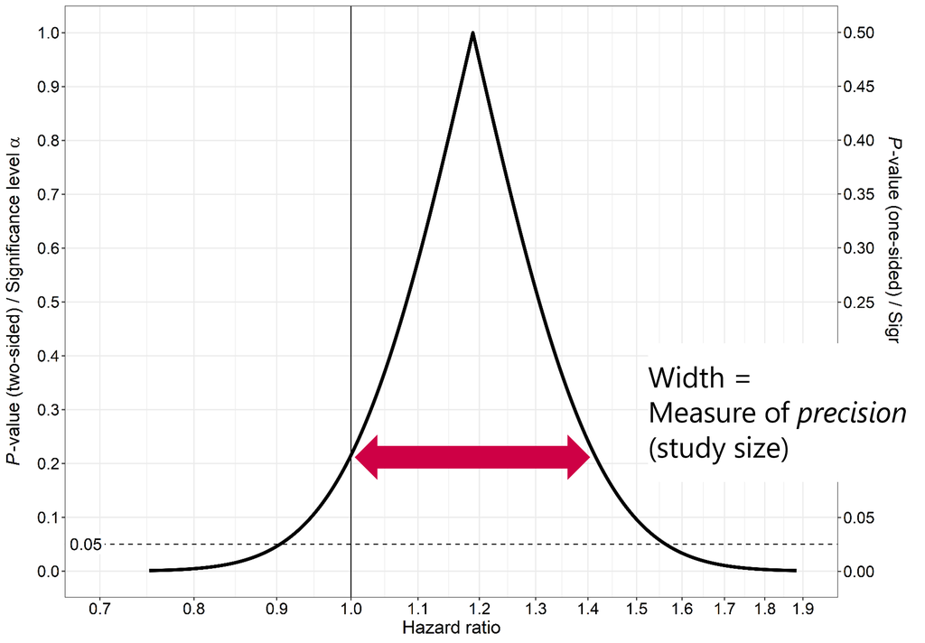

## We can read off the $p$-value for any null value from the $p$-value function

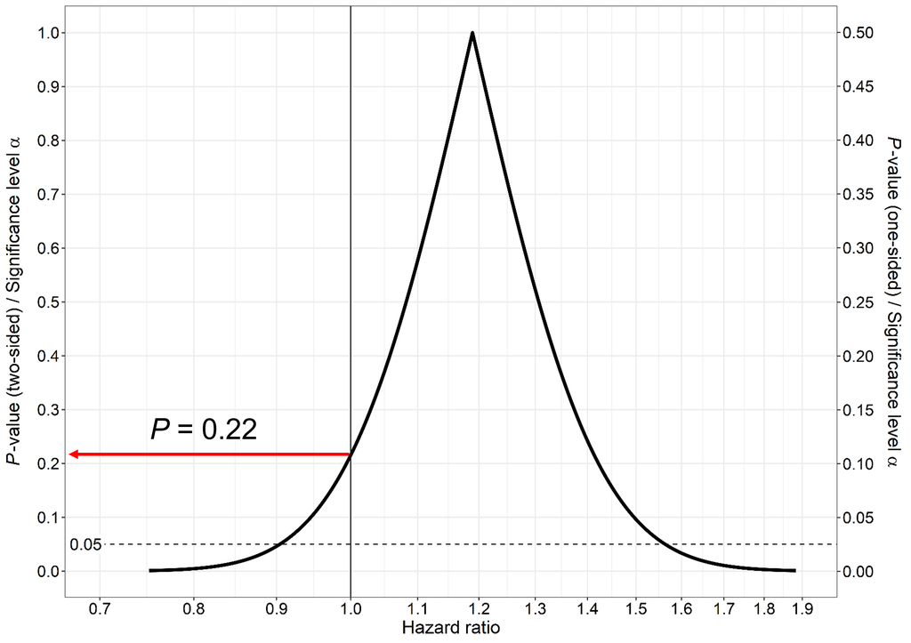

## Null misinterpretation

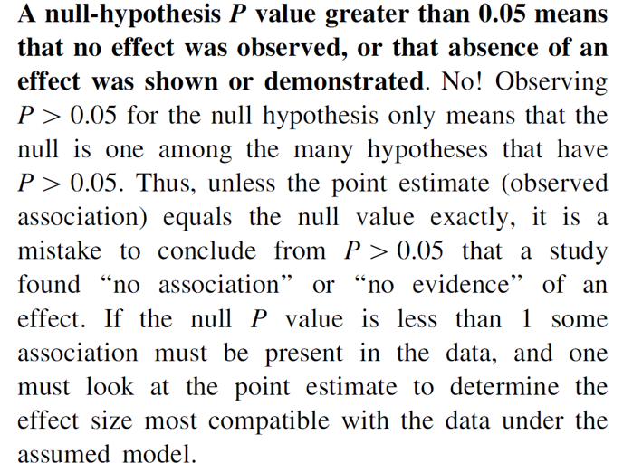

https://doi.org/10.1007/s10654-016-0149-3

## A better summary

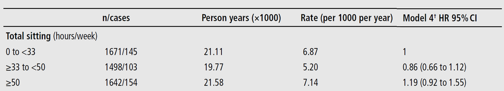

> “Our results are most compatible at the 95% level with an effect of high versus low amounts of sitting anywhere from an 8% hazard reduction to 55% increase in the hazard of diabetes.”

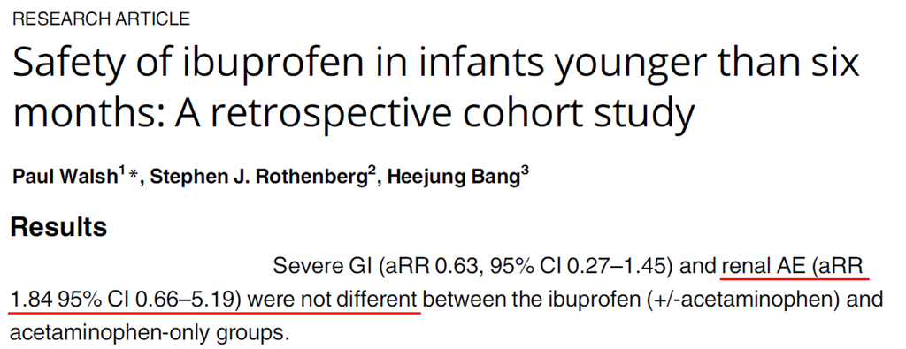

https://doi.org/10.1371/journal.pone.0199493

*Implication:* Ibuprofen is safe in terms of renal adverse effects (AE).

## Walsh et al. (2018): Safety of Ibuprofen

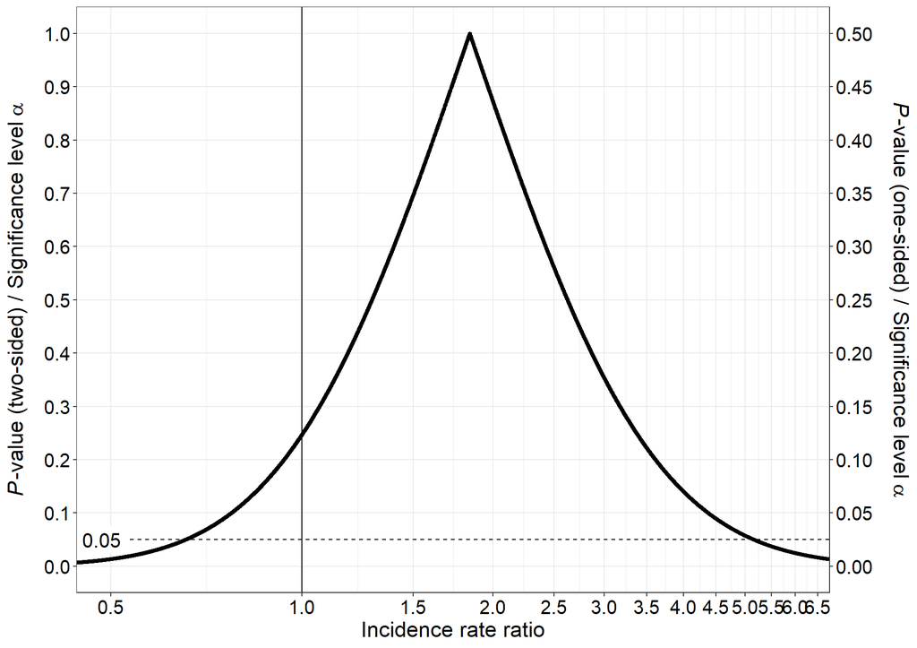

```r
walsh <- conf_dist(
  estimate = c(
    log(1.84)
  )
  , stderr = c(
    0.526
  )
  , type = "general_z"
  , plot_type = "p_val"
  , n_values = 1e4L
  , conf_level = c(0.95)
  , null_values = log(c(1))
  , trans = "exp"
  , alternative = "two_sided"
  , log_yaxis = FALSE
  , cut_logyaxis = 0.05
  , xlab = "Incidence rate ratio"
  , xlim = log(c(0.5, 6))
  , together = FALSE
  , plot_p_limit = 1-0.9999
  , plot_counternull = FALSE
)
```

How can we find the $p$-value of the hypothesis  
$\operatorname{H}_0:$ IRR = $1$ from the plot? $p \approx 0.25$

**Q:** How would you summarize the results?

## Walsh et al. (2018): Better conclusion

- The region of high (95%) compatibility for the incidence rate ratio: 0.66 to 5.19.
- Anything from a 34% rate reduction up to a fivefold increase!

> “Our study lacked sufficient information to reach useful inference about adverse renal events comparing ibuprofen to acetaminophen alone.”

## Does high power plus nonsignificance support the null?

Table 1: Hypothetical randomized trial data

|  | New treatment | Placebo |
| --- | --- | --- |
| Adverse events | 48 | 32 |
| Total | 1000 | 1000 |

- High power for $\operatorname{RR} = 2$ at $\alpha = 0.05$ (over 85%)
- $\widehat{\operatorname{RR}} = 1.50$ (95%-CI: $0.97$ to $2.33$)
- $P = 0.07$ for $\operatorname{H}_{0}: \operatorname{RR} = 1$
- Does this mean that the study supports the conclusion that new treatment is equal to placebo in terms of AEs? No!

## Does high power plus nonsignificance support the null?

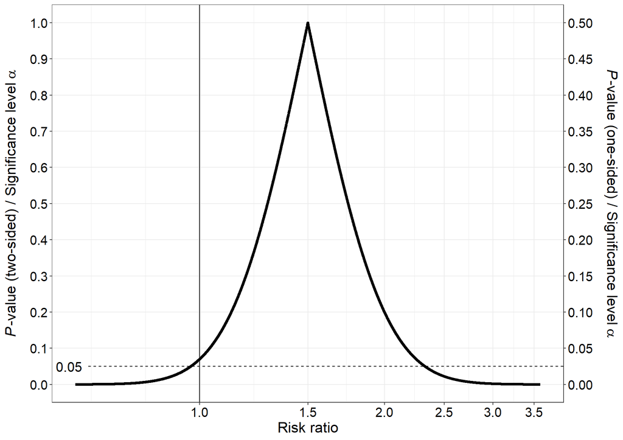

```r
walsh <- conf_dist(
  estimate = c(
    0.405465108108164
  )
  , stderr = c(
    0.2237931
  )
  , type = "general_z"
  , plot_type = "p_val"
  , n_values = 1e4L
  , conf_level = c(0.95)
  , null_values = log(c(1))
  , trans = "exp"
  , alternative = "two_sided"
  , log_yaxis = FALSE
  , cut_logyaxis = 0.05
  , xlab = "Risk ratio"
  # , xlim = log(c(0.5, 6))
  , together = FALSE
  , plot_p_limit = 1-0.9999
  , plot_counternull = FALSE
)
```

Based on the results, do the data favor $\operatorname{RR} = 1$ or $\operatorname{RR} = 2$?

- The point estimate is $1.5$: Closer to $2$ than to $1$ in proportional terms.
- $P$-value for $\operatorname{RR} = 2$ is $0.20$, 3 times the $p$-value for $\operatorname{RR} = 1$.
- $1$ is closer to lower CI limit than $2$ is to the upper limit (in proportional terms).

Summary: Despite “nonsignificance” and power approximating 90% for $\operatorname{RR} = 2$, the results favor $\operatorname{RR} = 2$ over $\operatorname{RR} = 1$! (Greenland, 2012)

# Comparing studies using $p$-value functions

[figure not shown]

https://doi.org/10.1056/nejmoa041152

*Implication:* No association for women with high alcohol consumption or effect differs between moderate and high consumption.

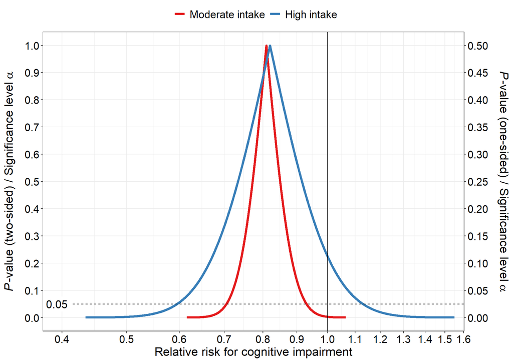

```r
stampfer <- conf_dist(
  estimate = c(
    log(0.81)
    , log(0.82)
  )
  , stderr = c(
    0.0704862
    , 0.163609
  )
  , type = "general_z"
  , plot_type = "p_val"
  , est_names = c("Moderate intake", "High intake")
  , n_values = 1e4L
  , conf_level = c(0.95)
  , null_values = log(c(1))
  , trans = "exp"
  , alternative = "two_sided"
  , log_yaxis = FALSE
  , cut_logyaxis = 0.05
  , xlab = "Relative risk for cognitive impairment"
  , xlim = log(c(0.4, 1.5))
  , together = TRUE
  , plot_p_limit = 1-0.9999
  , plot_counternull = FALSE
)
```

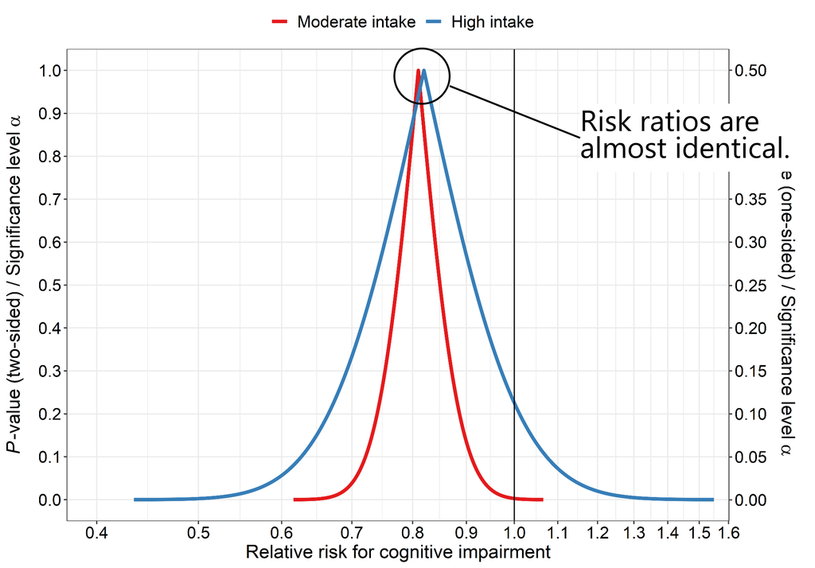

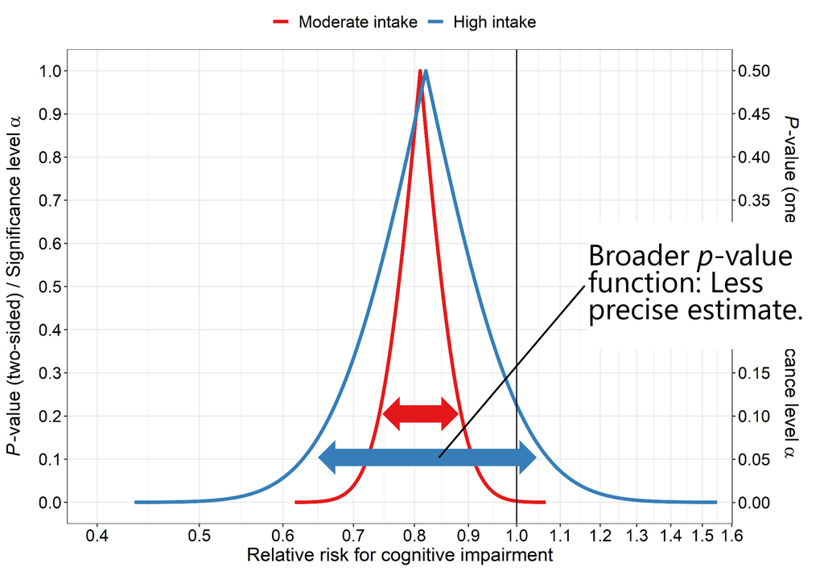

## Stampfer et al. (2005): A better summary

- No basis to infer that the effect size differs for moderate and heavy drinkers.
- The hypothesis that is most compatible with the data is almost the same in both groups.
- Lack of significance was driven by lower precision for heavy drinkers.

## NSAIDs and atrial fibrillation risk

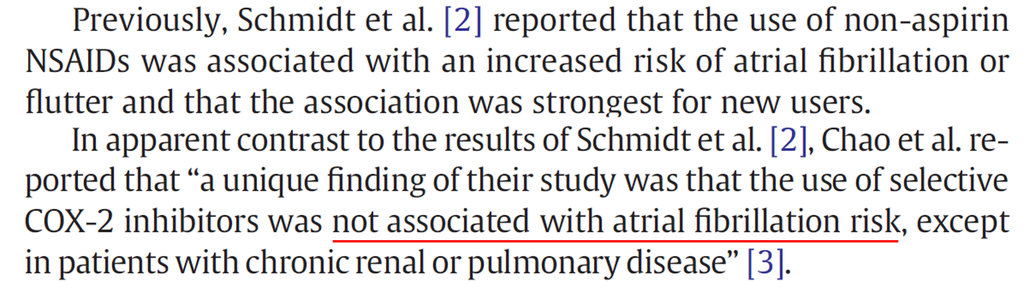

https://doi.org/10.1016/j.ijcard.2014.09.205

- [Schmidt et al. (2011)](https://doi.org/10.1136/bmj.d3450): RR = $1.20$ (95%-CI: $1.09$ to $1.33$) (“significant”)
- [Chao et al. (2013)](https://doi.org/10.1016/j.ijcard.2012.09.058): RR = $1.20$ (95%-CI: $0.97$ to $1.48$) (“not significant”)

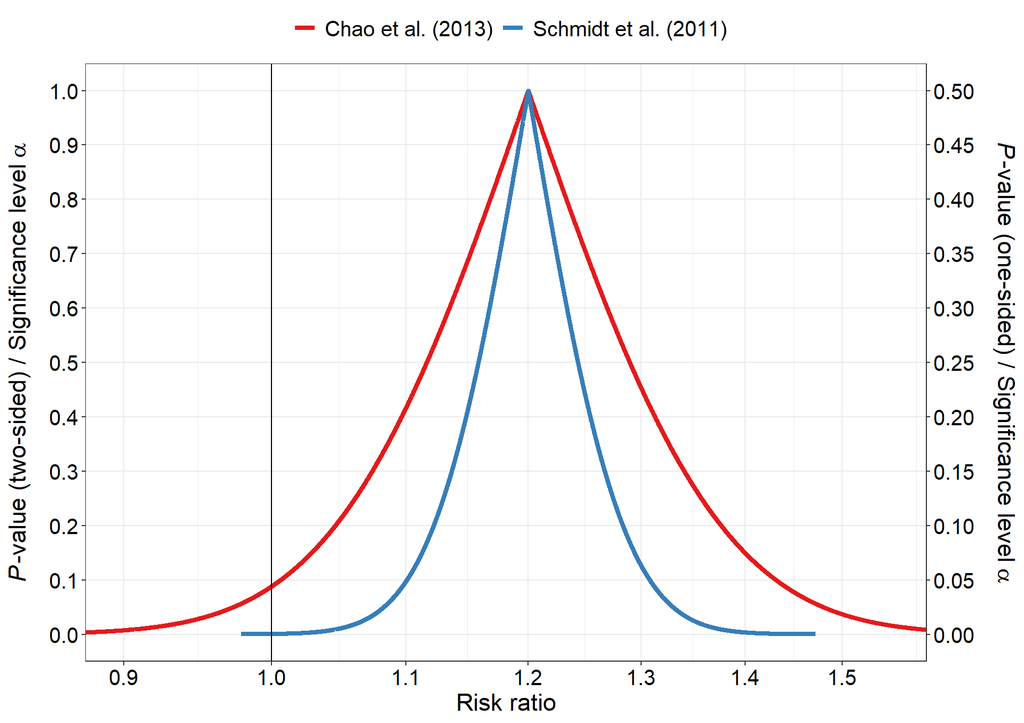

```r
schmidt <- conf_dist(
  estimate = c(
    log(1.20)
    , log(1.20)
  )
  , stderr = c(
    0.107002
    , 0.0524792
  )
  , type = "general_z"
  , plot_type = "p_val"
  , est_names = c("Chao et al. (2013)", "Schmidt et al. (2011)")
  , n_values = 1e4L
  # , conf_level = c(0.95)
  , null_values = log(c(1))
  , trans = "exp"
  , alternative = "two_sided"
  , log_yaxis = FALSE
  , cut_logyaxis = 0.05
  , xlab = "Risk ratio"
  , xlim = log(c(0.9, 1.55))
  , together = TRUE
  , plot_p_limit = 1-0.9999
  , plot_counternull = FALSE
)
```

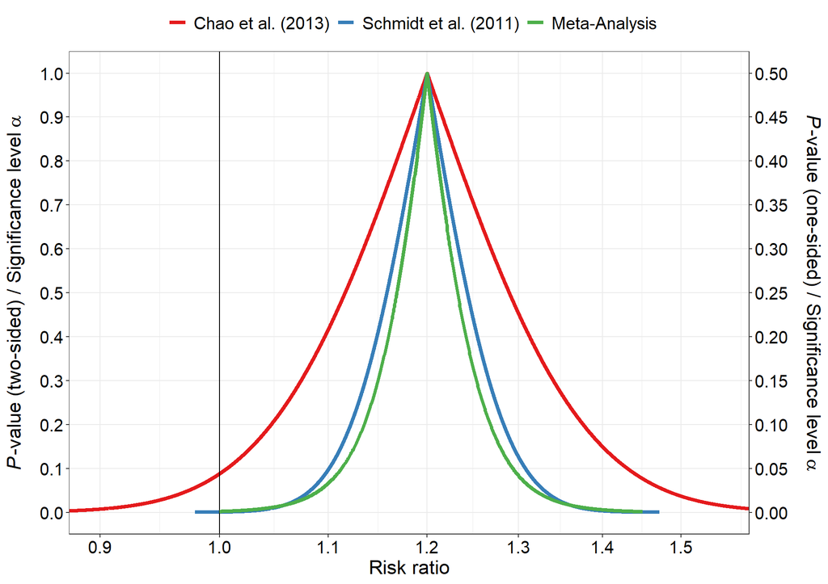

```r
schmidt_meta$plot +
  geom_line(data = meta_dat, aes(x = values, y = p_two), linewidth = 1.5)
```

## Summary $p$-value functions

- Display all possible confidence intervals/$p$-values
- Tip: Point estimate
- Width: Determined by standard error (precision)
- Standard error can be extracted from published confidence intervals or from $p$-value if not provided.
- Aliases: Confidence curve, compatibility curve, consonance curve, consonance function.

## Literature

[figure not shown]

https://doi.org/10.1002/sim.8293

## Software: R package [`pvaluefunctions`](https://cran.r-project.org/package=pvaluefunctions)

[figure not shown]

https://cran.r-project.org/package=pvaluefunctions

https://github.com/DInfanger/pvaluefunctions

## Software: R package [`parameters`](https://easystats.github.io/parameters/)

Allows the creation of $p$-value functions directly from models using the function [`p_function`](https://easystats.github.io/parameters/reference/p_function.html). Here is an example from a linear regression model:

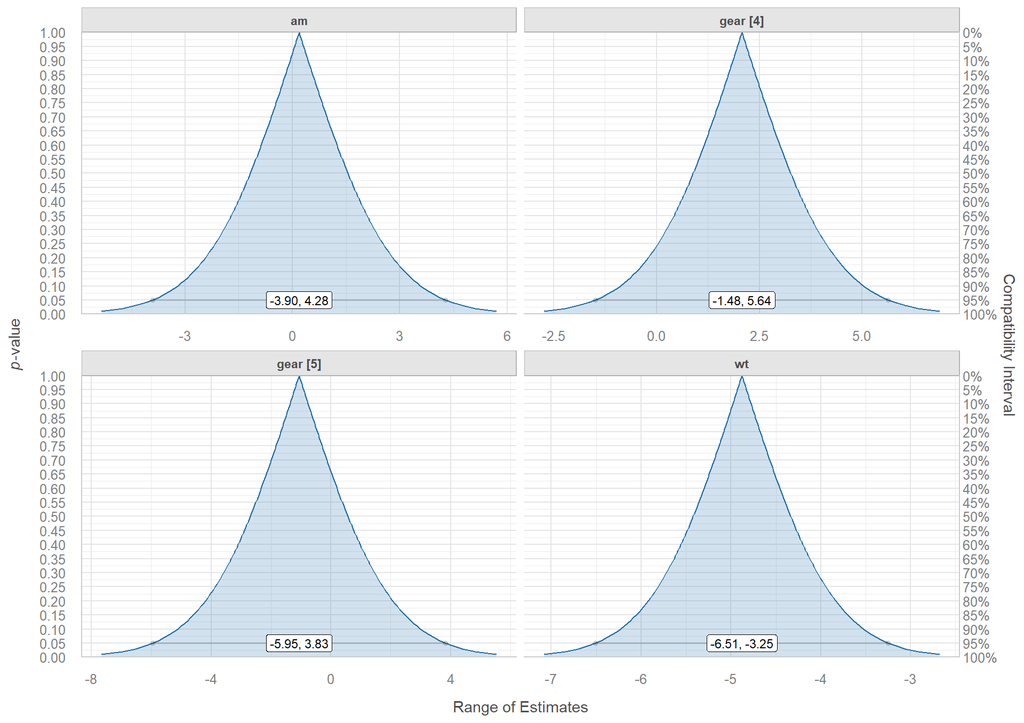

```r
mod <- lm(mpg ~ wt + as.factor(gear) + am, data = mtcars)
p_curve <- p_function(mod, ci_levels = c(emph = 0.95))

plot(p_curve, n_columns = 2)
```

## Take-Home-Messages

- The practice of dichotomizing results into “significant” and “not significant” is not informative (Gelman & Stern, 2006).
- Focus on effect sizes and confidence/compatibility intervals.
- $P$-value functions:
  - are more informative than commonly used summaries of study results.
  - require minimal training because they show familiar measures ($p$-values and confidence intervals).

## Take-Home-Messages

- Create $p$-value functions to summarize the available evidence and improve statistical reasoning:
  - Values with high and low compatibility with the data.
  - How informative was the study?
  - To compare evidence from different studies
  - Useful for meta-analyses (see Held et al., 2025; and Rücker & Schwarzer, 2021).
- Never say that “we found no effect/association” or “there was no difference” when $p>0.05$ (Greenland et al., 2016).

## Recommended reading

Bender, R., Berg, G., & Zeeb, H. (2005). Tutorial: Using Confidence Curves in Medical Research. *Biometrical Journal*, *47*(2), 237–247. https://doi.org/10.1002/bimj.200410104

Gelman, A., & Stern, H. (2006). The Difference Between “Significant” and “Not Significant” is not Itself Statistically Significant. *The American Statistician*, *60*(4), 328–331. https://doi.org/10.1198/000313006X152649

Greenland, S. (2012). Nonsignificance Plus High Power Does Not Imply Support for the Null Over the Alternative. *Annals of Epidemiology*, *22*(5), 364–368. https://doi.org/10.1016/j.annepidem.2012.02.007

Greenland, S. (2019). Valid P-Values Behave Exactly as They Should: Some Misleading Criticisms of P-Values and Their Resolution With S-Values. *The American Statistician*, *73*(sup1), 106–114. https://doi.org/10.1080/00031305.2018.1529625

Greenland, S., Senn, S. J., Rothman, K. J., Carlin, J. B., Poole, C., Goodman, S. N., & Altman, D. G. (2016). Statistical tests, P values, confidence intervals, and power: A guide to misinterpretations. *European Journal of Epidemiology*, *31*(4), 337–350. https://doi.org/10.1007/s10654-016-0149-3

Held, L., Hofmann, F., & Pawel, S. (2025). A comparison of combined p-value functions for meta-analysis. *Research Synthesis Methods*, *16*(5), 758–785. https://doi.org/10.1017/rsm.2025.26

Infanger, D., & Schmidt-Trucksäss, A. (2019). P value functions: An underused method to present research results and to promote quantitative reasoning. *Statistics in Medicine*, *38*(21), 4189–4197. https://doi.org/10.1002/sim.8293

Poole, C. (1987a). Beyond the confidence interval. *American Journal of Public Health*, *77*(2), 195–199. https://doi.org/10.2105/AJPH.77.2.195

Poole, C. (1987b). Confidence intervals exclude nothing. *American Journal of Public Health*, *77*(4), 492–493. https://doi.org/10.2105/AJPH.77.4.492

Rafi, Z., & Greenland, S. (2020). Semantic and cognitive tools to aid statistical science: Replace confidence and significance by compatibility and surprise. *BMC Medical Research Methodology*, *20*(1), 244. https://doi.org/10.1186/s12874-020-01105-9

Rosenthal, R., & Rubin, D. B. (1994). The Counternull Value of an Effect Size: A New Statistic. *Psychological Science*, *5*(6), 329–334. https://doi.org/10.1111/j.1467-9280.1994.tb00281.x

Rücker, G., & Schwarzer, G. (2021). Beyond the forest plot: The drapery plot. *Research Synthesis Methods*, *12*(1), 13–19. https://doi.org/10.1002/jrsm.1410